# Improving performance of R’s function rgeom

Bjarke Hautop Kristensen

2023-09-17

## Defining valid algorithm for sampling from a geomtric distribution

We will define our faster algorithm for sampling from a geometric distribution by using the following. We will use R’s definition of a geometric distribution, that is the number of failures before the first success. Let $X \sim \text{Geom}(p)$ and $Y \sim \text{Exp}(− \log(1 − p))$. Then $Z = \lfloor Y \rfloor$ has the same distribution as $X$.

**Click to expand: Proof**

$$\begin{aligned}
P(Z = k) &= P(k < Y \leq k+1) = P(Y\leq k+1)-P(Y<k) \\
&=1-e^{\log(1 − p)(k+1)}-(1-e^{\log(1 − p)k}) \\
&=(1-p)^{k}-(1-p)^{k+1} \\
&=(1-p)^{k} p
\end{aligned}$$

Using [inverse transform method](https://en.wikipedia.org/wiki/Inverse_transform_sampling) we can now define our algorithm by generating $n$ uniform numbers and transforming it by
$$Z=\lfloor Y \rfloor=\lfloor
\log(\text{Unif}(n)) / \log(1 - p)) \rfloor$$
We can also use the fact that if $U$ is a standard uniform then $W=-\log(U)$ is exponential distributed for our sampling.

We start by defining some candidate functions:

```r
# Candidate Functions for Sampling from a Geometric Distribution

# Candidate function 1: my_rgeom1
# Approach: Uses as.integer() to round down
my_rgeom1 <- function(n, prob) as.integer(log(runif(n)) / log(1 - prob))

# Candidate function 2: my_rgeom2
# Approach: Uses floor() to round down
my_rgeom2 <- function(n, prob) floor(log(runif(n)) / log(1 - prob))

# Candidate function 3: my_rgeom3
# Approach: Similar to my_rgeom1 but uses log1p()
my_rgeom3 <- function(n, prob) as.integer(log(runif(n)) / log1p(-prob))

# Candidate function 4: my_rgeom4
# Approach: Similar to my_rgeom2 but uses log1p()
my_rgeom4 <- function(n, prob) floor(log(runif(n)) / log1p(-prob))

# Candidate function 5: my_rgeom5
# Approach: Samples from exponential instead of uniform
my_rgeom5 <- function(n, prob) floor(-rexp(n) / log1p(-prob))

# Candidate function 6: my_rgeom6
# Approach: Similar to my_rgeom5 but uses as.integer()
my_rgeom6 <- function(n, prob) as.integer(-rexp(n) / log1p(-prob))
```

## Benchmarking functions

We will now benchmark these functions vs R’s rgeom() using the package `microbenchmark`

```r
set.seed(42)
library(microbenchmark)
n <- 1e6
prob <- runif(n)

microbenchmark(
  rgeom = rgeom(n, prob),
  my_rgeom1 = my_rgeom1(n, prob),
  my_rgeom2 = my_rgeom2(n, prob),
  my_rgeom3 = my_rgeom3(n, prob),
  my_rgeom4 = my_rgeom4(n, prob),
  my_rgeom5 = my_rgeom5(n, prob),
  my_rgeom6 = my_rgeom6(n, prob)
)
```

```
## Unit: milliseconds
##       expr      min        lq      mean    median        uq      max neval
##      rgeom 109.6922 115.82395 117.90042 117.39295 119.82355 128.9012   100
##  my_rgeom1  84.9299  89.97560  92.29534  91.85050  93.36980 122.7013   100
##  my_rgeom2  91.1611  96.47250  98.45688  98.04330  99.40290 126.2619   100
##  my_rgeom3  79.0175  86.26255  88.86164  88.27400  90.22410 119.0781   100
##  my_rgeom4  85.9024  91.48650  94.32510  93.88495  95.49555 121.1727   100
##  my_rgeom5  74.4831  77.14515  79.15923  78.99775  80.51705  90.5071   100
##  my_rgeom6  66.4379  71.38290  73.54606  73.13925  74.59730  98.8421   100
```

We notice all these outperform R’s implementation of rgeom() and that my_rgeom5() and my_rgeom(6) are the fastest.

## Testing output of my functions with rgeom()’s outputs.

To make it a fair comparison we need the functions to output the same type of object and handle invalid inputs the same.

**Click to expand: Checking if outputs are consistent**

```r
rgeom_all <- list(rgeom, my_rgeom1, my_rgeom2, my_rgeom3, my_rgeom4, my_rgeom5, my_rgeom6)
sapply(rgeom_all, \(f) typeof(f(1, 0.5)))
```

```
## [1] "integer" "integer" "double"  "integer" "double"  "double"  "integer"
```

Here we see the functions using as.integer() correctly gives object type integer but the ones using floor() does not.

```r
sapply(rgeom_all, \(f) typeof(f(1, .Machine$double.xmin)))
```

```
## [1] "double"  "integer" "double"  "integer" "double"  "double"  "integer"
```

But here the functions using as.integer() gets error since the range of representable integers is restricted to about $\pm 2 \cdot 10^9$.

### Testing how my functions handle invalid input

We will adapt our two fastest functions my_rgeom5() and my_rgeom6() to mimic behavior of rgeom(). We will also need to deal with how our functions handles invalid input.

**Click to expand: Checking how our functions handle invalid inputs**

```r
rgeom(1, -0.5)
```

```
## [1] NA
```

```r
my_rgeom5(1, -0.5)
```

```
## [1] -3
```

```r
my_rgeom6(1, -0.5)
```

```
## [1] -7
```

```r
rgeom(1, 0)
```

```
## [1] NA
```

```r
my_rgeom5(1, 0)
```

```
## [1] Inf
```

```r
my_rgeom6(1, 0)
```

```
## [1] NA
```

```r
rgeom(1, 1)
```

```
## [1] 0
```

```r
my_rgeom5(1, 1)
```

```
## [1] 0
```

```r
my_rgeom6(1, 1)
```

```
## [1] 0
```

```r
rgeom(1, 1.1)
```

```
## [1] NA
```

```r
my_rgeom5(1, 1.1)
```

```
## [1] NaN
```

```r
my_rgeom6(1, 1.1)
```

```
## [1] NA
```

```r
rgeom(1, 2)
```

```
## [1] NA
```

```r
my_rgeom5(1, 2)
```

```
## [1] NaN
```

```r
my_rgeom6(1, 2)
```

```
## [1] NA
```

In the above we saw some compatibility issues with our functions compared to rgeom(). We will now adress these by defining a new function my_rgeom()

## Adapting our function to mimic behavior of rgeom()

We will define our new function by combining my_rgeom5() and my_rgeom6():

```r
my_rgeom <- function(n, p) {
  y <- -rexp(n)/log1p(-p)
  y[p <= 0] <- NA_real_
  if (max(y, na.rm = TRUE) > .Machine$integer.max) floor(y) else as.integer(y)
}
```

We used the fastest method for sampling in line 1. In line 2 we then match expected output of rgeom() if $p \leq 0$. In line 3 we noticed that as.integer() was faster than floor(), however it requires the values aren’t too high to be stored as an integer.

This function correctly matches the output rgeom() gives, as seen below

**Click to expand: Comparison with R’s rgeom()**

```r
typeof(rgeom(1, 0.5))
```

```
## [1] "integer"
```

```r
typeof(my_rgeom(1, 0.5))
```

```
## [1] "integer"
```

```r
typeof(rgeom(1, .Machine$double.xmin))
```

```
## [1] "double"
```

```r
typeof(my_rgeom(1, .Machine$double.xmin))
```

```
## [1] "double"
```

```r
rgeom(1,0)
```

```
## [1] NA
```

```r
my_rgeom(1, 0)
```

```
## [1] NA
```

```r
rgeom(1, 1.1)
```

```
## [1] NA
```

```r
my_rgeom(1, 1.1)
```

```
## [1] NA
```

```r
rgeom(1, 2)
```

```
## [1] NA
```

```r
my_rgeom(1, 2)
```

```
## [1] NA
```

As we saw above our function my_rgeom() correctly matches output of rgeom()

## Benchmarking our final function vs R’s rgeom()

```r
set.seed(42)
n <- 1e6
prob <- runif(n)

benchmark_results <- microbenchmark(
  rgeom = rgeom(n, prob),
  my_rgeom = my_rgeom(n, prob)
)

benchmark_results
```

```
## Unit: milliseconds
##      expr      min        lq      mean    median        uq      max neval
##     rgeom 109.0486 113.34850 114.92387 114.06600 116.07635 147.9470   100
##  my_rgeom  69.8589  75.89555  77.51639  76.53525  78.03755 105.8639   100
```

We see my_rgeom() outperforms rgeom() by about 30 percentage.

And plotting the distribution of rgeom() and my_rgeom():

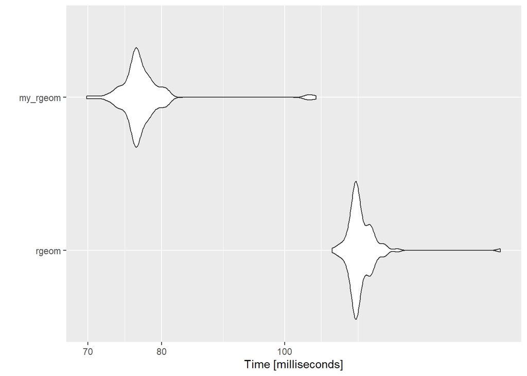

```r
library(ggplot2)
autoplot(benchmark_results)
```